# Week 5: Kinematics Problem-Solving Session

Weeks 3-4 Review: Forward and Inverse Kinematics

Basri Erdogan

# Overview

## Session Goal

Use one guided 180-minute block to revisit the main manipulator-kinematics skills from Weeks 3 and 4:

- build DH tables and forward kinematics chains
- recognize when position equations are simpler than the full matrix
- solve analytical IK for cylindrical, SCARA, and elbow robots
- apply kinematic decoupling for a spherical wrist

The original Week 5 numerical IK theory has been preserved in `theory/archive/numerical-ik-original/`.

## 180-Minute Plan

| Block | Focus | Time |
| --- | --- | --- |
| Problem 1 | Cylindrical (RPP) FK with DH | 15 min |
| Problem 2 | SCARA FK | 20 min |
| Problem 3 | Spherical wrist FK + ZYZ extraction | 25 min |
| Problem 4 | 3R elbow-arm FK position | 20 min |
| Problem 5 | Cylindrical (RPP) IK | 15 min |
| Problem 6 | SCARA IK (inverse of Problem 2) | 25 min |
| Problem 7 | 3R elbow-arm IK | 25 min |
| Problem 8 | 6-DOF wrist decoupling | 30 min |

## Working Rules

1. Start every problem by sketching the robot and naming the variables.
2. Decide early whether you need a full transform or only position equations.
3. Use `atan2` for every angle recovered from Cartesian coordinates.
4. Check reachability before solving inverse kinematics.
5. Verify each IK solution by plugging it back into FK.

# Part A: Forward Kinematics

## Problem 1: Cylindrical Manipulator FK

A cylindrical (RPP) robot has a fixed base height $d_1 = 0.50$ m.

Joint values: $\theta_1 = 60^\circ$, $d_2 = 0.35$ m, $d_3 = 0.65$ m

Tasks:

1. Write the DH table (identify which joints are R and P).
2. Build $T_1^0$, $T_2^1$, $T_3^2$.
3. Compute the end-effector position.
4. Explain how joint variables map to cylindrical coordinates.

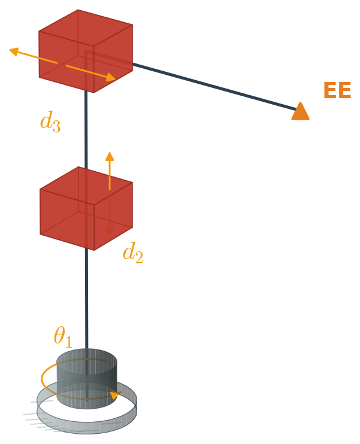

## Solution 1: Frame Assignment

**Step 1 — Assign z-axes** (along joint axes):

- $z_0$: vertical (base revolute)
- $z_1$: vertical (prismatic slide along $z_0$)
- $z_2$: horizontal/radial (prismatic extension)

**Step 2 — Assign x-axes** (DH rules):

- $x_0$: free choice (no link $-1$) → pick $\hat{x}_0 = [1,0,0]$
- $x_1$: $z_0 \parallel z_1$ → common normal direction, choose $\hat{x}_1 = \hat{x}_0$
- $x_2$: $z_1 \times z_2$ → $[0,0,1]\times[1,0,0] = [0,1,0]$

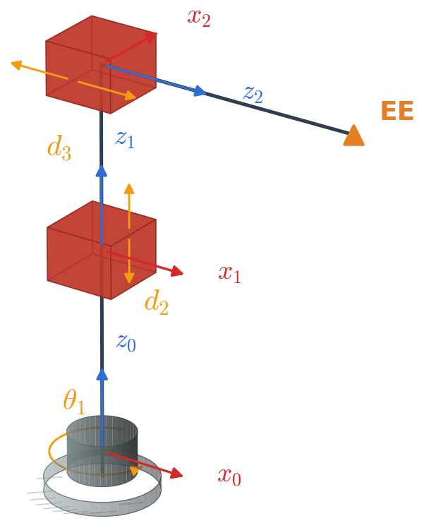

## Solution 1: Cylindrical Manipulator — DH Table & T Matrices (1/2)

| Link | $a_i$ | $\alpha_i$ | $d_i$ | $\theta_i$ | Joint |
| --- | --- | --- | --- | --- | --- |
| 1 | 0 | $0^\circ$ | 0.50 | $\theta_1$ | R |
| 2 | 0 | $90^\circ$ | $d_2$ | $90^\circ$ | P |
| 3 | 0 | $0^\circ$ | $d_3$ | 0 | P |

$$\small
T_1^0 =
\begin{bmatrix}
0.500 & -0.866 & 0 & 0 \\
0.866 & 0.500 & 0 & 0 \\
0 & 0 & 1 & 0.50 \\
0 & 0 & 0 & 1
\end{bmatrix}
\;\;
T_2^1 =
\begin{bmatrix}
0 & 0 & 1 & 0 \\
1 & 0 & 0 & 0 \\
0 & 1 & 0 & 0.35 \\
0 & 0 & 0 & 1
\end{bmatrix}
\;\;
T_3^2 =
\begin{bmatrix}
1 & 0 & 0 & 0 \\
0 & 1 & 0 & 0 \\
0 & 0 & 1 & 0.65 \\
0 & 0 & 0 & 1
\end{bmatrix}$$

$T_1^0$: base rotation $60^\circ$ + lift $d_1$. $\;T_2^1$: $90^\circ$ twist redirects $z_2$ vertical → radial. $\;T_3^2$: pure translation $d_3$ radially.

## Solution 1: Cylindrical Manipulator — Geometric Result (2/2)

$$x = d_3\cos\theta_1 = 0.65\cos 60^\circ = 0.3250\text{ m}$$
$$y = d_3\sin\theta_1 = 0.65\sin 60^\circ = 0.5629\text{ m}$$
$$z = d_1 + d_2 = 0.50 + 0.35 = 0.8500\text{ m}$$

The joint variables **are** cylindrical coordinates: $(\theta_1, z, r) = (\theta_1, d_1+d_2, d_3)$.

**Geometric interpretation:** $\theta_1$ sets the azimuth, $d_2$ sets the height above the base, and $d_3$ sets the radial reach. No coupling between joints — each controls exactly one cylindrical coordinate.

## Problem 2: SCARA Forward Kinematics

Use the Week 3 SCARA convention.

Given: $a_1 = 0.40$ m, $a_2 = 0.30$ m, $d_3 = 0.12$ m (prismatic), $d_4 = 0.08$ m (fixed tool offset), $\theta_1 = 20^\circ$, $\theta_2 = 40^\circ$, $\theta_4 = -30^\circ$

Tasks:

1. Write the DH table.
2. Compute the end-effector position.
3. Determine the net tool orientation relative to the base.
4. State whether the tool $z$-axis points upward or downward.

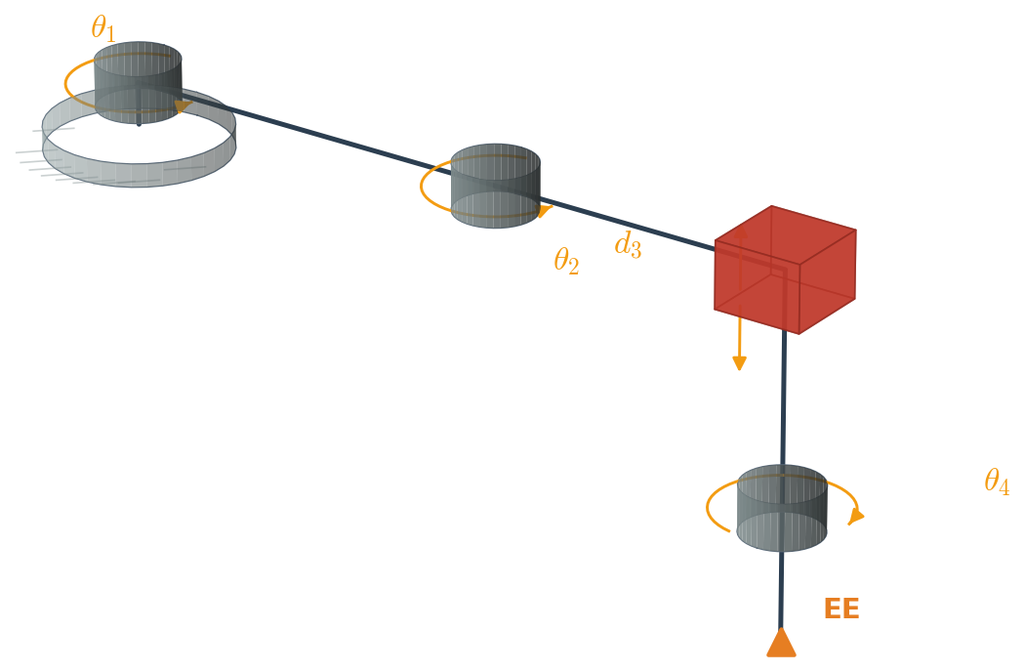

## Solution 2: Frame Assignment

**Step 1 — Assign z-axes:**

- $z_0, z_1$: vertical ($+z$), revolute axes
- $z_2$: vertical ($-z$), prismatic downward
- $z_3$: vertical ($-z$), revolute (tool spin)

**Step 2 — Assign x-axes:**

- $x_0$: free choice → $[1,0,0]$
- $x_1$: $z_0 \parallel z_1$ → same direction, $\hat{x}_1 = [1,0,0]$
- $x_2$: $z_1$ antiparallel to $z_2$ → common normal, choose $\hat{x}_2 = [1,0,0]$
- $x_3$: $z_2 \parallel z_3$ → $\hat{x}_3 = [1,0,0]$

All x-axes point in the same direction — a clean SCARA convention.

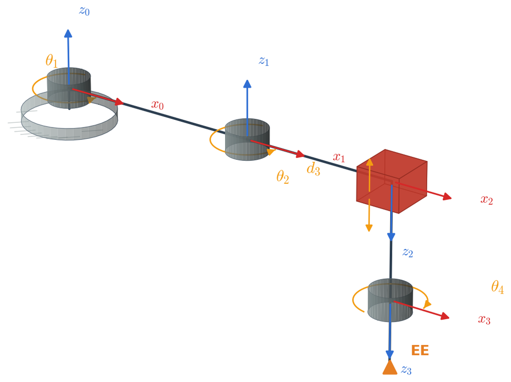

## Solution 2: SCARA — DH Table & T Matrices (1/2)

| Link | $a_i$ | $\alpha_i$ | $d_i$ | $\theta_i$ |
| --- | --- | --- | --- | --- |
| 1 | 0.40 | $0^\circ$ | 0 | $\theta_1$ |
| 2 | 0.30 | $180^\circ$ | 0 | $\theta_2$ |
| 3 | 0 | $0^\circ$ | $d_3$ | 0 |
| 4 | 0 | $0^\circ$ | $d_4$ | $\theta_4$ |

Key transforms (links with $a \neq 0$ or $\alpha \neq 0$):

$$\small
T_1^0 =
\begin{bmatrix}
0.940 & -0.342 & 0 & 0.376 \\
0.342 & 0.940 & 0 & 0.137 \\
0 & 0 & 1 & 0 \\
0 & 0 & 0 & 1
\end{bmatrix}
\qquad
T_2^1 =
\begin{bmatrix}
0.766 & 0.643 & 0 & 0.230 \\
0.643 & -0.766 & 0 & 0.193 \\
0 & 0 & -1 & 0 \\
0 & 0 & 0 & 1
\end{bmatrix}$$

$T_1^0$: rotation $20^\circ$ + translate $a_1$. $\;T_2^1$: rotation $40^\circ$ + translate $a_2$ — note $R_{33}=-1$ from $\alpha_2=180^\circ$ (z-flip!). $\;T_3^2, T_4^3$: translation $d_3$ then rotation $\theta_4$ + offset $d_4$.

## Solution 2: SCARA — Geometric Result (2/2)

$$\mathbf{p}_{ee} =
\begin{bmatrix}
a_1\cos\theta_1 + a_2\cos(\theta_1+\theta_2) \\
a_1\sin\theta_1 + a_2\sin(\theta_1+\theta_2) \\
-(d_3+d_4)
\end{bmatrix}
=
\begin{bmatrix}
0.5259 \\ 0.3966 \\ -0.2000
\end{bmatrix}\text{ m}$$

The net in-plane orientation is $\phi = \theta_1 + \theta_2 - \theta_4 = 90^\circ$.

Because $\alpha_2 = 180^\circ$ flips the $z$-axis between links 2 and 3, the tool $z$-axis points **downward** ($-z_0$ direction).

**Geometric interpretation:** The $xy$-position is a standard 2R planar arm. The $z$-position is set independently by $d_3$. The tool orientation $\phi$ accumulates from all revolute joints, but the minus sign on $\theta_4$ comes from the $180^\circ$ z-flip — rotation about $-z_0$ instead of $+z_0$.

## Problem 3: Spherical Wrist Orientation

For a spherical wrist, $R_6^3 = R_z(\theta_4)\,R_y(\theta_5)\,R_z(\theta_6)$

Given: $\theta_4 = 30^\circ$, $\theta_5 = 45^\circ$, $\theta_6 = -60^\circ$

Tasks:

1. Compute $R_6^3$.
2. Extract the approach vector $\mathbf{a}$ (third column).
3. State why this robot is called a spherical wrist.
4. **Now pretend you only have $R_6^3$** — recover $\theta_4$, $\theta_5$, $\theta_6$ using the ZYZ extraction formulas.

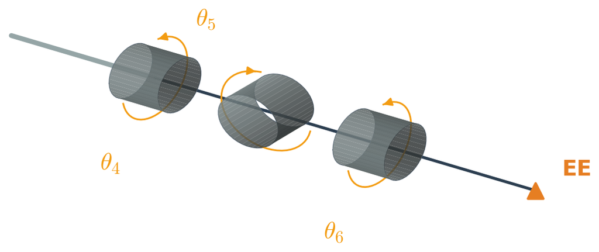

## Solution 3: Frame Assignment

**Step 1 — Assign z-axes** (ZYZ wrist):

- $z_3$: along forearm (first roll axis)
- $z_4$: perpendicular to forearm (pitch axis)
- $z_5$: along forearm (second roll axis)

$z_3 = z_5$ — the hallmark of a ZYZ spherical wrist.

**Step 2 — Assign x-axes** (all axes intersect):

- $x_3$: free choice (no preceding link) → pick $[0,0,-1]$
- $x_4$: $z_3 \times z_4 = \hat{x}\times\hat{y} = \hat{z}$; choose $-\hat{z}$ → $[0,0,-1]$ (gives $\alpha_4 = -90^\circ$ for ZYZ)
- $x_5$: $z_4 \times z_5 = \hat{y}\times\hat{x} = -\hat{z}$ → $[0,0,-1]$

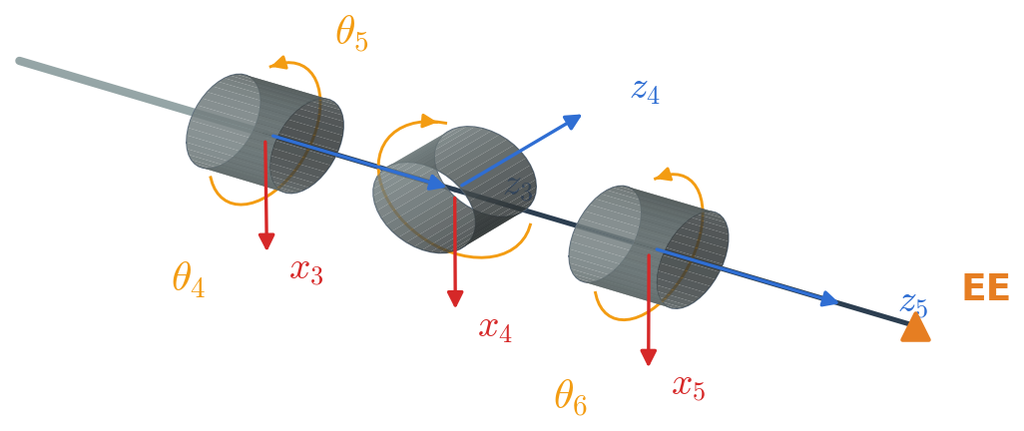

## Solution 3: Spherical Wrist — DH Table (1/3)

| Link | $a_i$ | $\alpha_i$ | $d_i$ | $\theta_i$ |
| --- | --- | --- | --- | --- |
| 4 | 0 | $-90^\circ$ | 0 | $\theta_4$ |
| 5 | 0 | $90^\circ$ | 0 | $\theta_5$ |
| 6 | 0 | $0^\circ$ | $d_6$ | $\theta_6$ |

All axes intersect → $a=0$, $d=0$ for links 4–5. Build each transform using $T = R_z(\theta)\,T_z(d)\,T_x(a)\,R_x(\alpha)$:

$$\small
T_4^3 =
\begin{bmatrix}
0.866 & 0 & -0.5 & 0 \\
0.5 & 0 & 0.866 & 0 \\
0 & -1 & 0 & 0 \\
0 & 0 & 0 & 1
\end{bmatrix}
\;\;
T_5^4 =
\begin{bmatrix}
0.707 & 0 & 0.707 & 0 \\
0.707 & 0 & -0.707 & 0 \\
0 & 1 & 0 & 0 \\
0 & 0 & 0 & 1
\end{bmatrix}
\;\;
T_6^5 =
\begin{bmatrix}
0.5 & 0.866 & 0 & 0 \\
-0.866 & 0.5 & 0 & 0 \\
0 & 0 & 1 & 0.6 \\
0 & 0 & 0 & 1
\end{bmatrix}$$

$T_4^3$, $T_5^4$ have zero columns — the $\pm 90^\circ$ twists collapse one axis, creating the ZYZ decomposition.

## Solution 3: Spherical Wrist — Forward Result (2/3)

$$\small
T_6^3 = T_4^3\,T_5^4\,T_6^5 =
\begin{bmatrix}
0.739 & 0.280 & 0.612 & 0.367 \\
-0.573 & 0.739 & 0.354 & 0.212 \\
-0.354 & -0.612 & 0.707 & 0.424 \\
0 & 0 & 0 & 1
\end{bmatrix}$$

The $\pm 90^\circ$ twists make $R_6^3 = R_z(\theta_4)\,R_y(\theta_5)\,R_z(\theta_6)$ (ZYZ).

**Column interpretation:**

- **$\hat{x}_6$** (col 1): tool $x$-axis in frame 3
- **$\hat{y}_6$** (col 2): tool $y$-axis in frame 3
- **$\hat{z}_6$** (col 3): tool $z$-axis in frame 3
- **$\mathbf{p}$** (col 4): tip at $d_6=0.60$ m along $\hat{z}_6$

**Tool $z$-axis** $\hat{z}_6 = [0.612,\; 0.354,\; 0.707]^T$:

- $\theta_4 = 30^\circ$: azimuth (spin around forearm)
- $\theta_5 = 45^\circ$: elevation (tilt from forearm)
- $\theta_6 = -60^\circ$: roll about approach axis

**Position check:** $\|\mathbf{p}\| = 0.60$ m $= d_6$ $\checkmark$

Called a *spherical wrist* because joints 4–6 intersect at one point — they control orientation without moving the wrist center.

## Solution 3: Spherical Wrist — ZYZ Extraction (3/3)

For $R_6^3 = R_z(\theta_4)\,R_y(\theta_5)\,R_z(\theta_6)$, the extraction formulas are:

$$\theta_5 = \operatorname{atan2}\!\left(\sqrt{r_{13}^2+r_{23}^2},\; r_{33}\right) = \operatorname{atan2}(0.7071, 0.7071) = 45^\circ$$

$$\theta_4 = \operatorname{atan2}(r_{23}, r_{13}) = \operatorname{atan2}(0.3536, 0.6124) = 30^\circ$$

$$\theta_6 = \operatorname{atan2}(r_{32}, -r_{31}) = \operatorname{atan2}(-0.6124, 0.3536) = -60^\circ$$

The recovered angles match the original input — this confirms both the matrix and the extraction.

These are the same formulas you will use in Problem 8 to solve the wrist sub-problem.

## Problem 4: 3R Elbow-Arm FK Position

A 3R elbow robot has: $d_1 = 0.30$ m, $a_2 = 0.40$ m, $a_3 = 0.30$ m, $\theta_1 = 45^\circ$, $\theta_2 = 30^\circ$, $\theta_3 = -60^\circ$

Tasks:

1. Compute $r = a_2\cos\theta_2 + a_3\cos(\theta_2+\theta_3)$.
2. Compute $x$, $y$, and $z$.
3. Explain why decomposing into base rotation + vertical-plane 2-link problem simplifies both FK and IK.

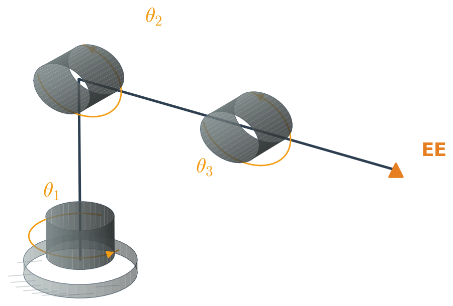

## Solution 4: Frame Assignment

**Step 1 — Assign z-axes:**

- $z_0$: vertical (base revolute) → $[0,0,1]$
- $z_1, z_2$: horizontal, perpendicular to arm plane (shoulder & elbow pitch) → $[0,-1,0]$

**Step 2 — Assign x-axes:**

- $x_0$: free choice → $[1,0,0]$
- $x_1$: $z_0 \times z_1 = [0,0,1]\times[0,-1,0] = [1,0,0]$ (natural direction)
- $x_2$: $z_1 \parallel z_2$ → common normal, $\hat{x}_2 = [1,0,0]$

All x-axes point radially outward in the arm plane — simplifying the position equations.

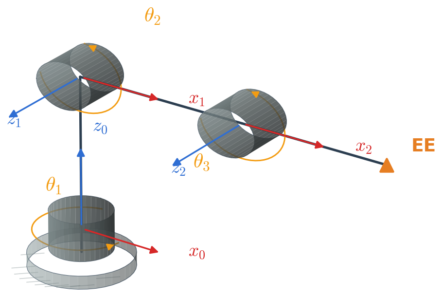

## Solution 4: 3R Elbow-Arm — DH Table & T Matrices (1/2)

| Link | $a_i$ | $\alpha_i$ | $d_i$ | $\theta_i$ |
| --- | --- | --- | --- | --- |
| 1 | 0 | $90^\circ$ | 0.30 | $\theta_1$ |
| 2 | 0.40 | $0^\circ$ | 0 | $\theta_2$ |
| 3 | 0.30 | $0^\circ$ | 0 | $\theta_3$ |

$$\small
T_1^0 =
\begin{bmatrix}
0.707 & 0 & 0.707 & 0 \\
0.707 & 0 & -0.707 & 0 \\
0 & 1 & 0 & 0.30 \\
0 & 0 & 0 & 1
\end{bmatrix}
\;\;
T_2^1 =
\begin{bmatrix}
0.866 & -0.500 & 0 & 0.346 \\
0.500 & 0.866 & 0 & 0.200 \\
0 & 0 & 1 & 0 \\
0 & 0 & 0 & 1
\end{bmatrix}
\;\;
T_3^2 =
\begin{bmatrix}
0.500 & 0.866 & 0 & 0.150 \\
-0.866 & 0.500 & 0 & -0.260 \\
0 & 0 & 1 & 0 \\
0 & 0 & 0 & 1
\end{bmatrix}$$

$T_1^0$: base rotation $45^\circ$ + lift $d_1$ — zero columns from $90^\circ$ twist decouple base from arm plane. $\;T_2^1, T_3^2$: planar rotations with link translations ($\alpha=0$, pure 2R).

## Solution 4: 3R Elbow-Arm — Geometric Result (2/2)

The $\alpha_1 = 90^\circ$ twist decouples into: base rotation $\theta_1$ around $z_0$, then a 2-link planar arm in the vertical plane.

$$r = a_2\cos\theta_2 + a_3\cos(\theta_2+\theta_3) = 0.40\cos 30^\circ + 0.30\cos(-30^\circ) = 0.6062\text{ m}$$

$$x = r\cos 45^\circ = 0.4287\text{ m},
\qquad
y = r\sin 45^\circ = 0.4287\text{ m}$$

$$z = d_1 + a_2\sin 30^\circ + a_3\sin(-30^\circ)
= 0.30 + 0.20 - 0.15 = 0.35\text{ m}$$

$$\mathbf{p}_{ee} =
\begin{bmatrix}
0.4287 \\ 0.4287 \\ 0.3500
\end{bmatrix}\text{ m}$$

**Geometric interpretation:** $\theta_1$ selects the vertical plane (azimuth). Inside that plane, $r$ is the horizontal reach and $s = z - d_1$ is the vertical reach — both determined by the 2R chain ($\theta_2, \theta_3$). This same decomposition reappears in IK (Problem 7).

# Part B: Inverse Kinematics

## Problem 5: Cylindrical Manipulator IK

Same cylindrical robot as Problem 1: $d_1 = 0.50$ m.

Workspace limits: $0 \le d_2 \le 0.60$ m, $0.10 \le d_3 \le 0.80$ m.

Target:

$\mathbf{p}_{target} = \begin{bmatrix} 0.3000 & 0.4000 & 0.7500 \end{bmatrix}^T$ m

Tasks:

1. Check reachability (workspace limits).
2. Solve for $\theta_1$, $d_2$, $d_3$.
3. State how many IK solutions exist and why.
4. Verify with FK.

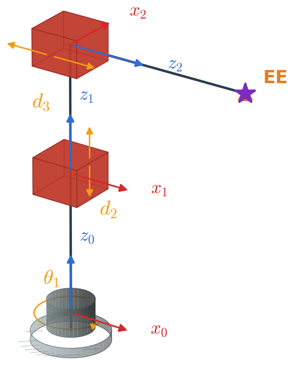

## Solution 5: Cylindrical Manipulator IK

Convert Cartesian to cylindrical coordinates directly:

$$\theta_1 = \operatorname{atan2}(y,x) = \operatorname{atan2}(0.4000, 0.3000) = 53.13^\circ$$

$$d_3 = \sqrt{x^2+y^2} = \sqrt{0.09+0.16} = 0.5000\text{ m}$$

$$d_2 = z - d_1 = 0.7500 - 0.5000 = 0.2500\text{ m}$$

Workspace check: $0 \le 0.25 \le 0.60$ $\checkmark$, $\;0.10 \le 0.50 \le 0.80$ $\checkmark$

The IK solution is **unique** — no multiple branches. This is because the cylindrical robot has no coupled revolute joints; each joint maps directly to one cylindrical coordinate.

**FK check:** $x = 0.50\cos 53.13^\circ = 0.3000$, $y = 0.50\sin 53.13^\circ = 0.4000$, $z = 0.50 + 0.25 = 0.75$ $\checkmark$

## Problem 6: SCARA Inverse Kinematics

Same SCARA as Problem 2: $a_1 = 0.40$ m, $a_2 = 0.30$ m, $d_4 = 0.08$ m

Target: $\mathbf{p} = \begin{bmatrix} 0.5259 & 0.3966 & -0.2000 \end{bmatrix}^T$ m, $\phi = 90^\circ$

Tasks:

1. Check reachability (planar component).
2. Solve 2R sub-problem for $\theta_1$, $\theta_2$ (both branches).
3. Solve for $d_3$ from the $z$-equation.
4. Solve for $\theta_4$ from orientation constraint.
5. Verify one solution matches Problem 2.

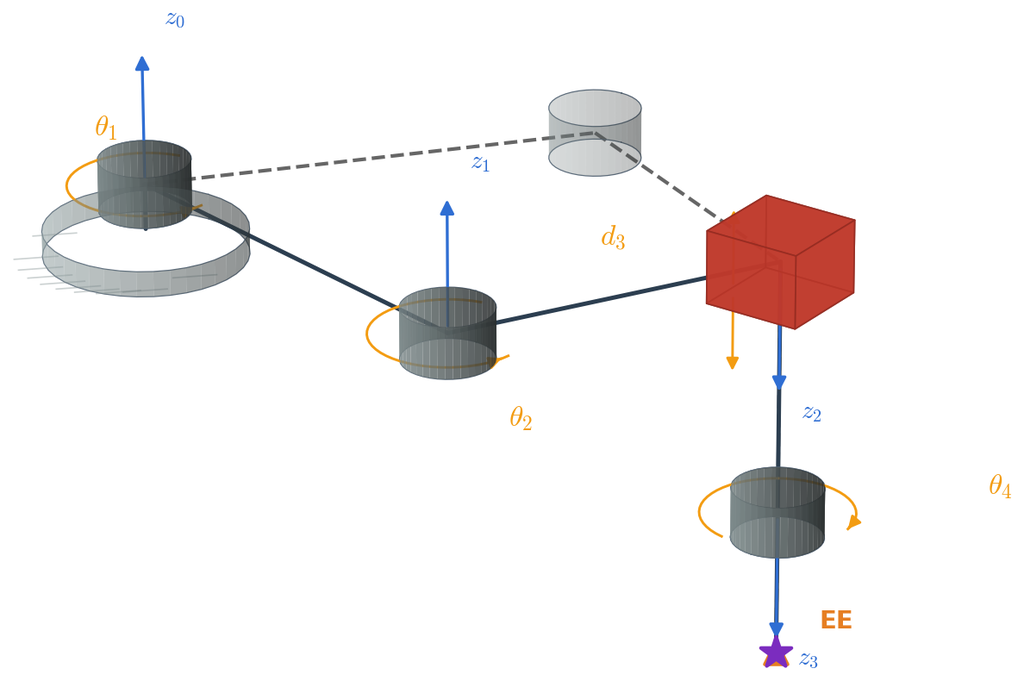

## Solution 6: SCARA Inverse Kinematics

Reachability: $r = \sqrt{0.5259^2+0.3966^2} = 0.6587$ m. Since $0.10 \le 0.6587 \le 0.70$, reachable.

$$\cos\theta_2 = \frac{r^2 - a_1^2 - a_2^2}{2a_1a_2} = 0.7660
\qquad\Longrightarrow\qquad
\theta_2 = \pm 40^\circ$$

With $\theta_2$ known, solve for $\theta_1$ from the position equations:

$$\theta_1 = \operatorname{atan2}(p_y,\, p_x) - \operatorname{atan2}(a_2\sin\theta_2,\; a_1 + a_2\cos\theta_2)$$

From $z = -(d_3 + d_4)$: $\;d_3 = -z - d_4 = 0.20 - 0.08 = 0.12$ m. $\;$ From $\phi = \theta_1 + \theta_2 - \theta_4$: $\;\theta_4 = \theta_1 + \theta_2 - 90^\circ$

|  | $\theta_1$ | $\theta_2$ | $d_3$ | $\theta_4$ |
| --- | --- | --- | --- | --- |
| **Elbow-up** | $20.00^\circ$ | $40.00^\circ$ | 0.12 m | $-30.00^\circ$ |
| **Elbow-down** | $54.04^\circ$ | $-40.00^\circ$ | 0.12 m | $-75.96^\circ$ |

**FK check** (elbow-up): $x = 0.40\cos 20^\circ + 0.30\cos 60^\circ = 0.5259$, $y = 0.40\sin 20^\circ + 0.30\sin 60^\circ = 0.3966$ $\checkmark$ — matches Problem 2.

## Solution 6: SCARA IK — Top-Down Projection

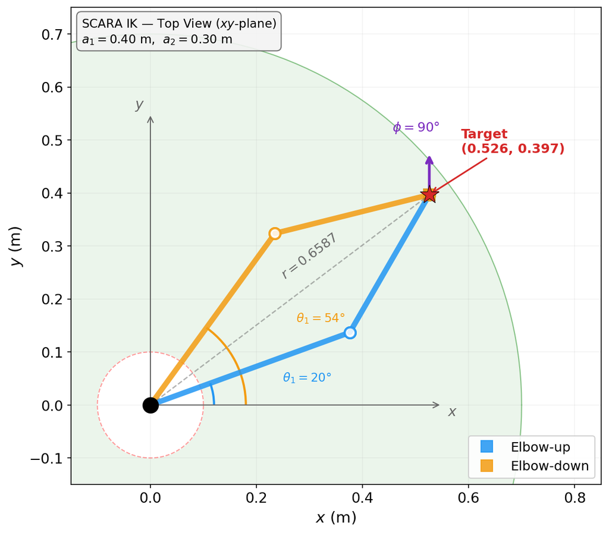

Both solutions reach the same target — elbow-up (blue) folds the second link **left**, elbow-down (orange) folds it **right**. The tool orientation $\phi = 90^\circ$ points along $+y$ regardless of branch.

## Problem 7: 3R Elbow-Arm IK

Same robot as Problem 4: $d_1 = 0.30$ m, $a_2 = 0.40$ m, $a_3 = 0.30$ m

Target: $\mathbf{p} = \begin{bmatrix} 0.4287 & 0.4287 & 0.3500 \end{bmatrix}^T$ m

Tasks:

1. Solve for $\theta_1$.
2. Reduce to a 2-link arm in the vertical plane.
3. Find both elbow configurations.
4. Verify both solutions with FK.

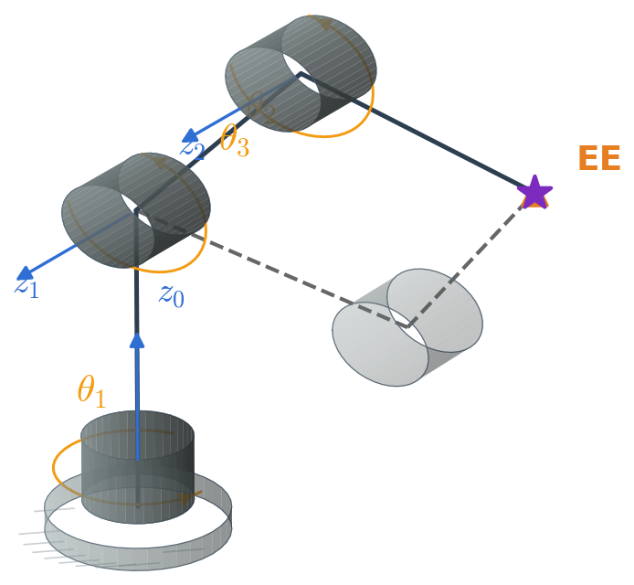

## Solution 7: 3R Elbow-Arm IK

Base angle: $\theta_1 = \operatorname{atan2}(0.4287, 0.4287) = 45^\circ$

Planar target: $r = \sqrt{x^2+y^2} = 0.6062$, $\;s = z-d_1 = 0.0500$

$$\cos\theta_3 = \frac{r^2+s^2-a_2^2-a_3^2}{2a_2a_3} = 0.5
\qquad\Longrightarrow\qquad
\theta_3 = \pm 60^\circ$$

$$\theta_2 = \operatorname{atan2}(s,r) - \operatorname{atan2}(a_3\sin\theta_3,\; a_2+a_3\cos\theta_3)$$

|  | $\theta_1$ | $\theta_2$ | $\theta_3$ |
| --- | --- | --- | --- |
| **Elbow-up** | $45^\circ$ | $-20.57^\circ$ | $60^\circ$ |
| **Elbow-down** | $45^\circ$ | $30^\circ$ | $-60^\circ$ |

**FK check** (elbow-down): $r = 0.40\cos 30^\circ + 0.30\cos(-30^\circ) = 0.6062$, $x = 0.6062\cos 45^\circ = 0.4287$ $\checkmark$ — matches Problem 4.

## Solution 7: 3R Elbow IK — 2D Projections

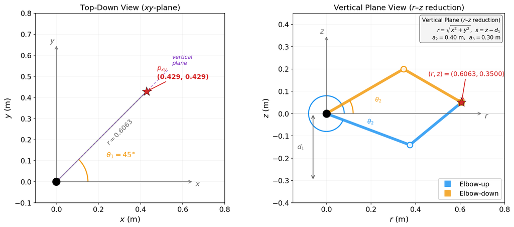

**Left:** Top-down view — $\theta_1 = 45^\circ$ selects the vertical plane, $r$ is the radial distance to the target projection. **Right:** Inside that vertical plane, the 2R arm ($a_2, a_3$) reaches $(r, s)$ with two elbow configurations.

## Problem 8: 6-DOF Spherical-Wrist Decoupling

6-DOF articulated arm, spherical wrist, $d_6 = 0.10$ m.

$\mathbf{p}_{ee} = [0.4814,\; 0.4263,\; 0.4948]^T$ m

$$\small
R_6^0 =
\begin{bmatrix}
0.9498 & -0.3129 & 0.0014 \\
0.3047 & 0.9256 & 0.2244 \\
-0.0715 & -0.2127 & 0.9745
\end{bmatrix}$$

Position solution $\theta_1\!=\!40^\circ$, $\theta_2\!=\!30^\circ$, $\theta_3\!=\!-50^\circ$ gives:

$$\small
R_3^0 =
\begin{bmatrix}
0.7198 & -0.6428 & -0.2620 \\
0.6040 & 0.7660 & -0.2198 \\
0.3420 & 0 & 0.9397
\end{bmatrix}$$

Tasks:

1. Compute $\mathbf{p}_{wc} = \mathbf{p}_{ee} - d_6\mathbf{z}_6$.
2. Compute $R_6^3 = (R_3^0)^T R_6^0$.
3. Extract $\theta_4$, $\theta_5$, $\theta_6$ (ZYZ formulas).

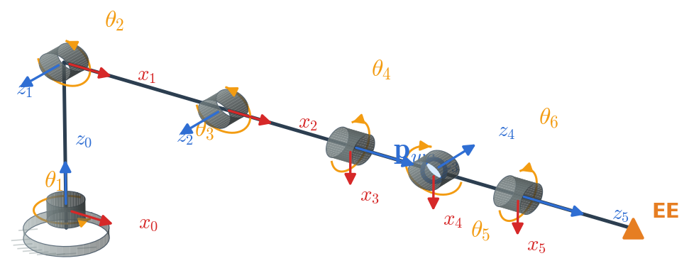

## Solution 8: 6-DOF Spherical-Wrist Decoupling

From the third column of $R_6^0$: $\;\mathbf{z}_6 = [0.0014,\; 0.2244,\; 0.9745]^T$

$$\small
\mathbf{p}_{wc}
=
\begin{bmatrix}
0.4814 \\ 0.4263 \\ 0.4948
\end{bmatrix}
- 0.10
\begin{bmatrix}
0.0014 \\ 0.2244 \\ 0.9745
\end{bmatrix}
=
\begin{bmatrix}
0.4813 \\ 0.4039 \\ 0.3974
\end{bmatrix}\text{ m}$$

$$\small
R_6^3 = (R_3^0)^T R_6^0 =
\begin{bmatrix}
0.8433 & 0.2611 & 0.4698 \\
-0.3771 & 0.9102 & 0.1710 \\
-0.3830 & -0.3214 & 0.8660
\end{bmatrix}$$

ZYZ extraction (same as Problem 3): $\;\theta_5 = \operatorname{atan2}(\sqrt{0.4698^2+0.1710^2},\; 0.8660) = 30^\circ$

$$\theta_4 = \operatorname{atan2}(0.1710, 0.4698) = 20^\circ, \qquad
\theta_6 = \operatorname{atan2}(-0.3214, 0.3830) = -40^\circ$$

**Wrist solution:** $(\theta_4,\theta_5,\theta_6) = (20^\circ, 30^\circ, -40^\circ)$

## Solution 8: Decoupling — Top-Down Projection

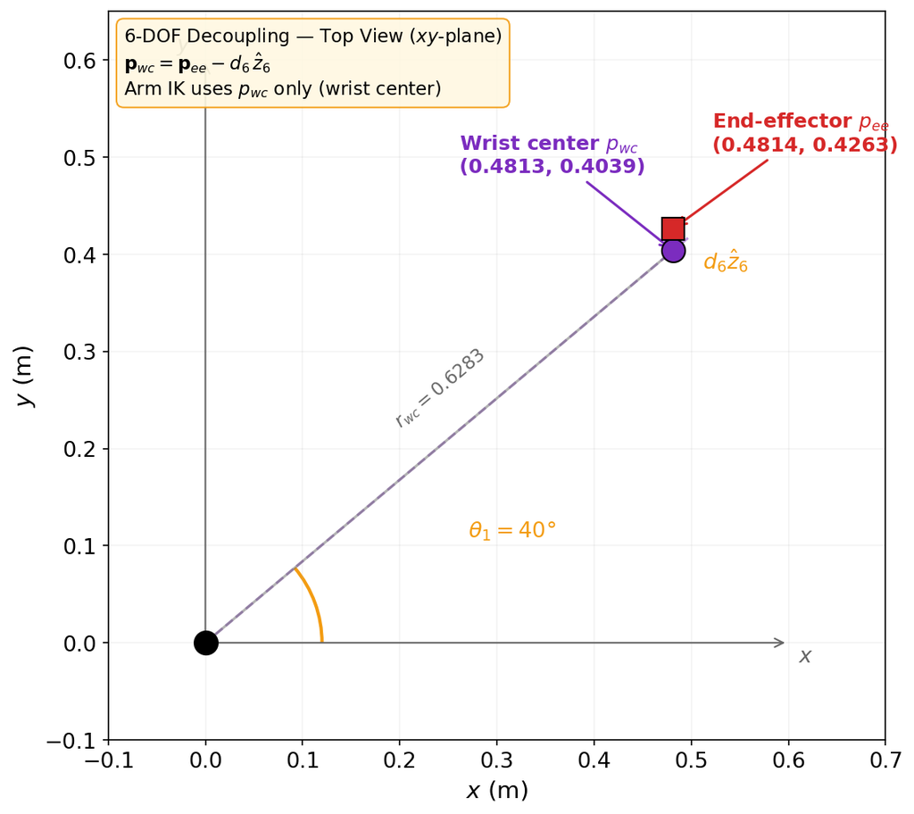

The wrist center $\mathbf{p}_{wc}$ (purple) is offset from the end-effector $\mathbf{p}_{ee}$ (red) by $d_6\hat{z}_6$. The arm IK solves for $\theta_1, \theta_2, \theta_3$ using $\mathbf{p}_{wc}$ only — the wrist joints don’t affect the wrist center position.

## Wrap-Up

The recurring pattern across all eight problems is:

1. write the kinematic model cleanly
2. reduce the geometry before doing algebra
3. separate arm position from wrist orientation whenever possible
4. verify every inverse solution with forward kinematics